# Part II - (Student Success Factors)

## by (Faisal Khan)

## Investigation Overview

For the presentation, I focus on just the influence of the four main features on students' academic performance. I start with the parents' education level, followed by the parent's job earnings, then plot the relationship between family structure and students' performance. I've made sure to use different color palettes for each quality variable to make sure it is clear that they're different between plots.

## Dataset Overview

PISA is a survey of students' skills and knowledge as they approach the end of compulsory education. It is not a conventional school test. Rather than examining how well students have learned the school curriculum, it looks at how well prepared they are for life beyond school. Around 510,000 students in 65 economies took part in the PISA 2012 assessment of reading, mathematics, and science representing about 28 million 15-year-olds globally. Of those economies, 44 took part in an assessment of the creative problem solving and 18 in an assessment of financial literacy.

## (Visualization 1)

According to the plot, it can clearly be seen that as the deucation level of parents increases there would also be an increase in academic performance of their children with the academic average score for students with parents of no eductioan being around 400 and children with the academic average score for students with graduated parents around 500.

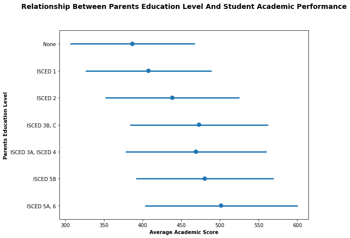

## (Visualization 2)

This plot depicts the relationship between the job earning of the family and the performance of their children at school. As parents job revenue increases, the yellow boxes(more populated areas) shift upward right in the chart which means there is a strong correlation between parents occupation and academic achievement of their children. However, each occupational level consists of almost all kind of scores. It is worth noticing that extraordinary high academic scores only happen at occupation pays more than 50K per year.

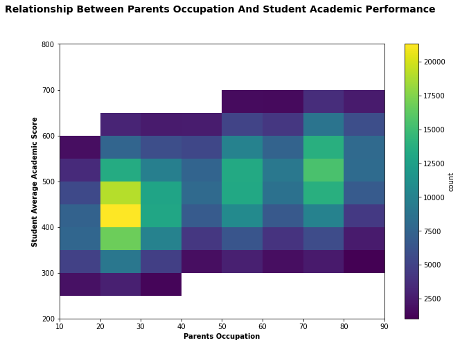

## (Visualization 3)

The other important factor while investigating the performance of the students is their family structure. According to the dataset, students living in families with at least one parent earn at least 50 scores more than other students on average. Children need a peaceful environment in order to be able to display their talents.

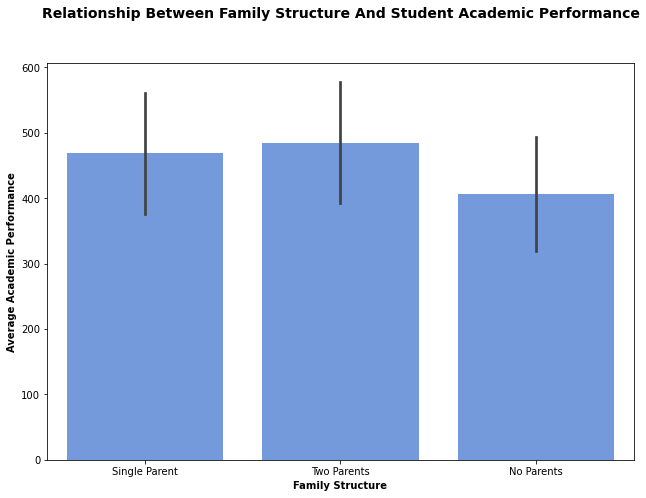

## (Visualization 4)

last but not least, the country in which a child resides can play a role in his or her academic success. Overally, countries with higher avg_status_index perform good (above 500) and countries with lower avg_status_index do not have a very good performance(below 450). However, some countries like Qatar,UAE and China go against this trend.

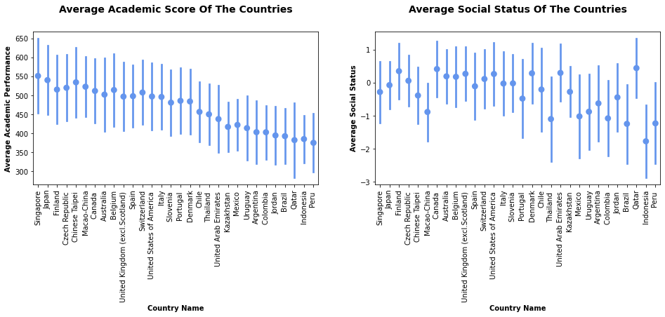